# Final Project

# Analyzing Fast-food nutrients

The data seems to be in a fine format. The “salad” column does not seem to provide any information so it is better to drop it. Another notable shortcoming of the dataset is that it does not include the weight of the meals which would allow us for a better analysis. Keeping that in mind the main question is: if you are hungry and you really want to go to a fast food restaurant, which one should you choose based on its overall nutrient values? To allow a better understanding it is better to change the raw values into percentage values. We use the FDA recommendations for a 2000 calorie diet to do that. (https://www.fda.gov/media/135301/download) It is clear from the source of original dataset (https://fastfoodnutrition.org/mcdonalds/artisan-grilled-chicken-sandwich) that it uses the same measurements (g,mg, etc.) as the FDA recommendations. Vitamins only have to be converted by decimals as they were in percent measurement from the start.

## Creating percentage table

```r
fast_food_percent <- fastfood_calories %>%
    select(1:4, 18:30)
```

## Which places to go?

Which restaurant offers food with the least overall calories?

```r
fast_food_percent %>%
      group_by(restaurant)%>%
     summarize(mean_calories = mean(calories))%>%
     arrange(mean_calories)
```

```
## # A tibble: 8 x 2
##   restaurant  mean_calories
##   <chr>               <dbl>
## 1 Chick Fil-A          384.
## 2 Taco Bell            444.
## 3 Subway               503.
## 4 Dairy Queen          520.
## 5 Arbys                533.
## 6 Burger King          609.
## 7 Sonic                632.
## 8 Mcdonalds            640.
```

### Creating information about the most unhealthy foodstuffs

It would be good to see which are the articles in the list that have a value of more than 1 (to see which article will cover more than what you need for one day and thus is probably best avoided)

```
## # A tibble: 77 x 2
##    restaurant item
##    <chr>      <chr>
##  1 Mcdonalds  Double Bacon Smokehouse Burger
##  2 Mcdonalds  Grilled Bacon Smokehouse Chicken Sandwich
##  3 Mcdonalds  Double Quarter Pounder® with Cheese
##  4 Mcdonalds  Crispy Maple Bacon Dijon Chicken Sandwich
##  5 Mcdonalds  6 piece Buttermilk Crispy Chicken Tenders
##  6 Mcdonalds  10 piece Buttermilk Crispy Chicken Tenders
##  7 Mcdonalds  12 piece Buttermilk Crispy Chicken Tenders
##  8 Mcdonalds  20 piece Buttermilk Crispy Chicken Tenders
##  9 Mcdonalds  40 piece Chicken McNuggets
## 10 Mcdonalds  6 piece Sweet N' Spicy Honey BBQ Glazed Tenders
## # ... with 67 more rows
```

It would also be good to know what are the items that have high and low salt and fat (the two most common ingredients, fast food chaines are criticized for). A plot is made to visualize the items that have very high salt and/or fat in them and which restaurant produces them and also a table is made to see which are the exact products that are most dangerous.

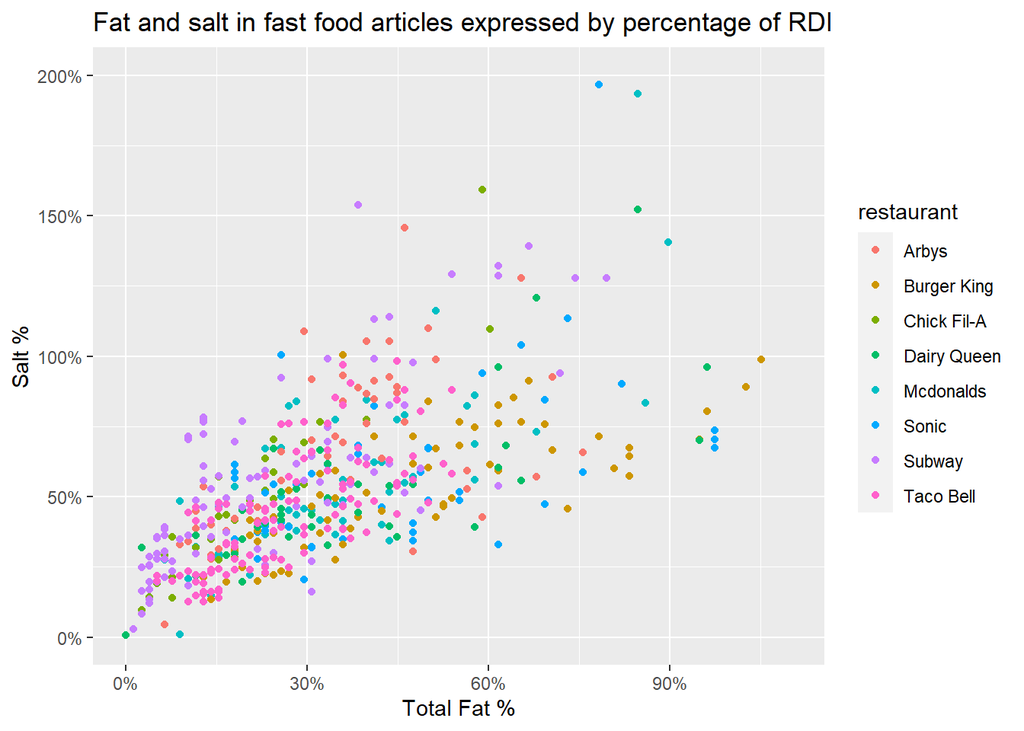

```
## # A tibble: 36 x 18
##       X1 restaurant item  calories total_fat_perc sat_fat_perc trans_fat_perc
##    <dbl> <chr>      <chr>    <dbl>          <dbl>        <dbl>          <dbl>
##  1    38 Mcdonalds  10 p~     1210          0.897        0.6            0.05
##  2    39 Mcdonalds  12 p~     1510          1.13         0.75           0.05
##  3    40 Mcdonalds  20 p~     2430          1.81         1.2            0.1
##  4    45 Mcdonalds  40 p~     1770          1.37         0.9            0.025
##  5    47 Mcdonalds  6 pi~      960          0.513        0.3            0
##  6    48 Mcdonalds  10 p~     1600          0.846        0.5            0
##  7    70 Chick Fil~ 30 p~      970          0.590        0.125          0
##  8    83 Chick Fil~ Chic~      860          0.603        0.8            0.05
##  9    99 Sonic      Supe~     1280          1.18         1.8            0.2
## 10   102 Sonic      Supe~     1220          1.12         1.7            0.2
## # ... with 26 more rows, and 27 more variables: cholesterol_perc <dbl>,
## #   sodium_perc <dbl>, total_carb_perc <dbl>, fiber_perc <dbl>,
## #   sugar_perc <dbl>, protein_perc <dbl>, vit_a_perc <dbl>, vit_c_perc <dbl>,
## #   calcium_perc <dbl>, calories_perc <dbl>, healthy[,"X1"] <dbl>,
## #   [,"restaurant"] <dbl>, [,"item"] <dbl>, [,"calories"] <dbl>,
## #   [,"total_fat_perc"] <dbl>, [,"sat_fat_perc"] <dbl>,
## #   [,"trans_fat_perc"] <dbl>, [,"cholesterol_perc"] <dbl>,
## #   [,"sodium_perc"] <dbl>, [,"total_carb_perc"] <dbl>, [,"fiber_perc"] <dbl>,
## #   [,"sugar_perc"] <dbl>, [,"protein_perc"] <dbl>, [,"vit_a_perc"] <dbl>,
## #   [,"vit_c_perc"] <dbl>, [,"calcium_perc"] <dbl>, [,"calories_perc"] <dbl>
```

On the other hand there are some that have very low fat and salt. It would be good to see whether these are in fact healthy picks in a restaurant. Which nutrients do these food consist of?

To explore the low end of this scale, we need a (somewhat arbitrary) cut-off point in the data. For this analysis I will use 15 and 25% percent points which seems like a good limit as the values are quite small but there are still a fair amount of points inside. The points need to be lower in both axis to qualify. For the high end the points the limits are less arbitrary. I’m interested in the items that reach 100% in at least one of the categories, so it will be enough for a point to be larger than 100% on one of the scales. The rest of the distribution is the Normal category.

```
## # A tibble: 3 x 2
##   healthy mean_calories
##   <chr>           <dbl>
## 1 High            1089.
## 2 Normal           521.
## 3 Low              174.
```

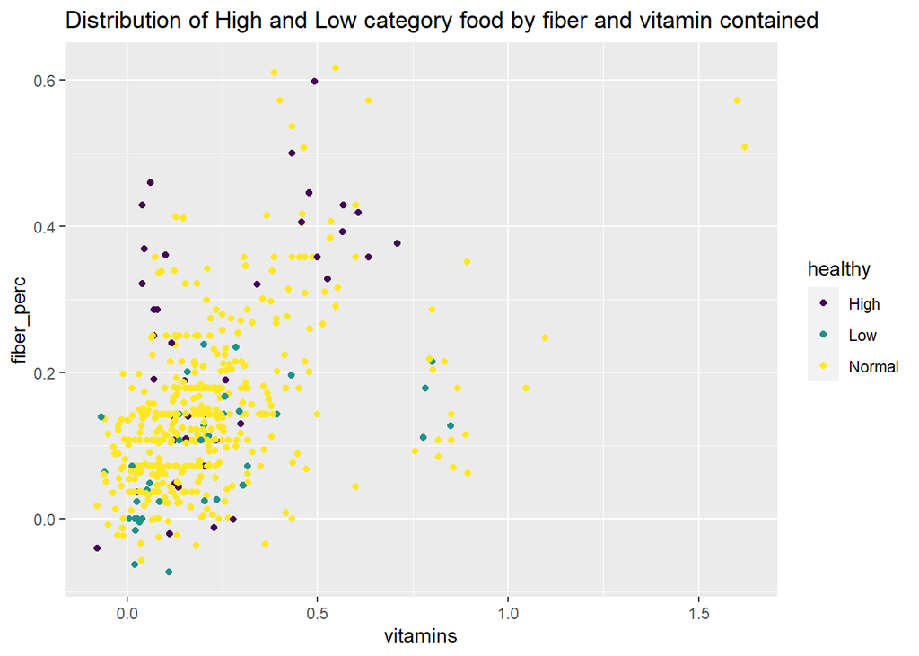

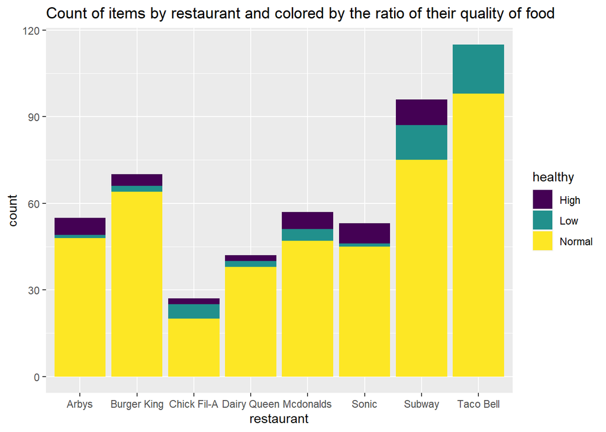

## Searching for healthy food

Unhealthy food is already listed, now it is time to search for healthy food that have high vitamins and high fibre but low fat and low sodium. Also it is time to add sugar to the unhealthy spectrum and see what are the items that are low on that as well.

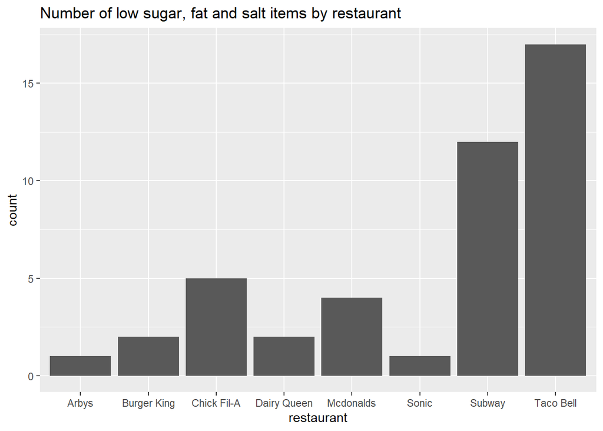

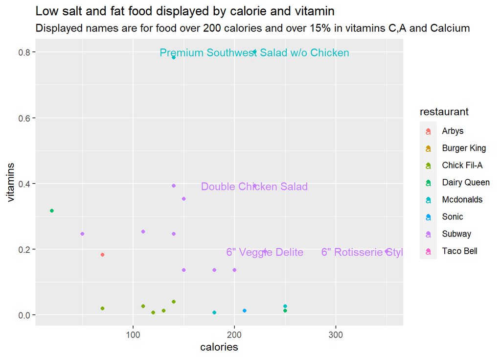

```
## # A tibble: 15 x 2
##    restaurant  item
##    <chr>       <chr>
##  1 Subway      "6\" Rotisserie Style Chicken"
##  2 Taco Bell   "Gordita Supreme® - Chicken"
##  3 Taco Bell   "Gordita Supreme® - Steak"
##  4 Burger King "Hamburger"
##  5 Mcdonalds   "Hamburger"
##  6 Dairy Queen "Breaded Mushrooms"
##  7 Subway      "6\" Veggie Delite"
##  8 Taco Bell   "Soft Taco Supreme® – Beef"
##  9 Mcdonalds   "Premium Southwest Salad w/o Chicken"
## 10 Subway      "Double Chicken Salad"
## 11 Sonic       "Corn Dog"
## 12 Subway      "Kids Mini Sub Roast Beef"
## 13 Taco Bell   "Nacho Cheese Doritos® Locos Tacos Supreme"
## 14 Taco Bell   "Soft Taco-Beef"
## 15 Taco Bell   "Spicy Tostada"
```

Subway and Taco Bell has most of this kind of food but the one that will cover most of your vitamin needs for not too many claories comes from McDonalds. A list of all recommended food containing at least 200 calories to lower hunger but containing low salt, sugar and fat is also provided (as the scatterplot missed many data-points due to NAs on vitamins.)

## Testing

Note: I found it hard to come up with a test that is interesting in any ways as all the variables relate to the ingredients of the food. For instance a variable containing ratings of the items would have been very useful.

What are the ingredients that increase calories the most?

First it is time to replace NAs in the fiber and protein variable with the mean.

```
## # A tibble: 1 x 1
##   mean_fiber
##        <dbl>
## 1       4.14
```

```
## # A tibble: 1 x 1
##   mean_protein
##          <dbl>
## 1         27.9
```

```
## # A tibble: 15 x 13
##    calories total_fat sodium total_carb fiber sugar protein .fitted .resid
##       <dbl>     <dbl>  <dbl>      <dbl> <dbl> <dbl>   <dbl>   <dbl>  <dbl>
##  1      100        64   2070         65   4      12    39      982. -882.
##  2     1550       126   1820         21   3       7   134     1715. -165.
##  3      590        59   1510         59   4      14    26      860. -270.
##  4      640        10   1280         44  10      16    46      447.  193.
##  5     1220        80   2050         62   4.1    15    27.9   1066.  154.
##  6     1000        61   4520         70   5      12    23      934.   66.3
##  7     1350       100   2180         69   4      10    23     1250.  100.
##  8     1040        48   1900         48   1      10    57      846.  194.
##  9     2430       141   6080        103   2       3   186     2409.   20.5
## 10      350        14    960         29  15       3    37      383.  -33.5
## 11      950        55   1530         50   5       0    51      888.   62.5
## 12     1140        52   3200         92  10      16    66     1096.   43.9
## 13     1280        92   1630         44   2       7    67     1249.   30.8
## 14      780        14   1600        112  16      16    46      751.   29.2
## 15      560        30    980         40   4      34    29      538.   22.3
## # ... with 4 more variables: .std.resid <dbl>, .hat <dbl>, .sigma <dbl>,
## #   .cooksd <dbl>
```

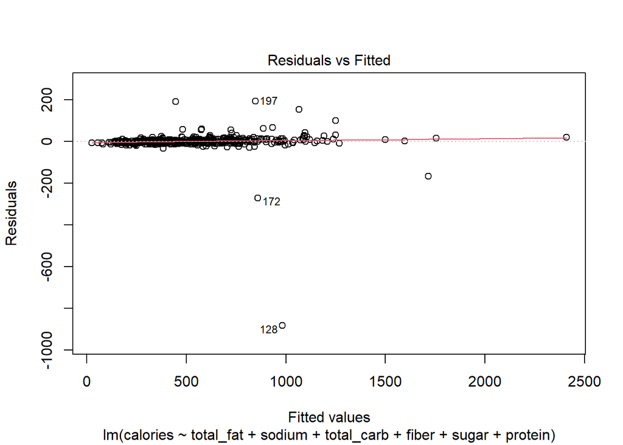

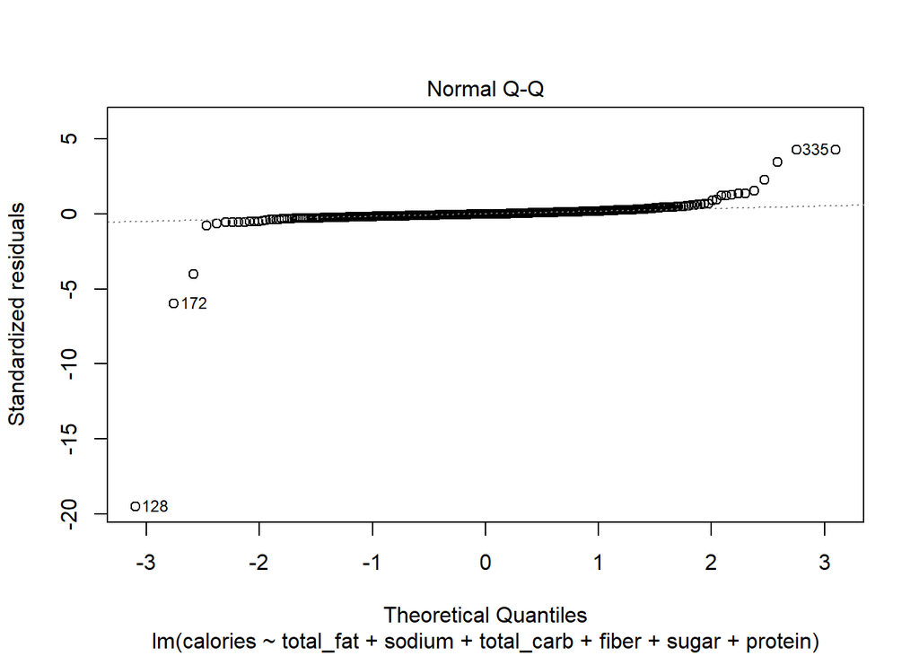

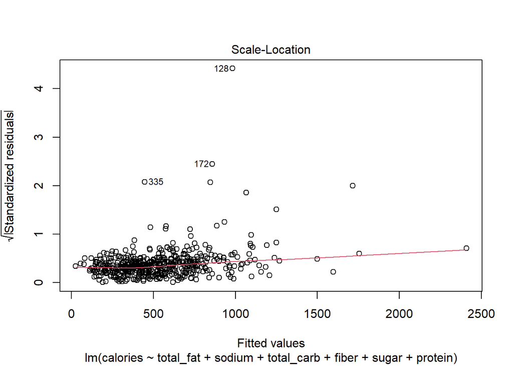

```
##             total_fat    sodium total_carb      fiber     sugar   protein
## total_fat  1.00000000 0.6691816  0.4225433 0.03496045 0.2593702 0.7135948
## sodium     0.66918158 1.0000000  0.6719755 0.29717036 0.4229934 0.7659294
## total_carb 0.42254327 0.6719755  1.0000000 0.64623757 0.5470262 0.4741970
## fiber      0.03496045 0.2971704  0.6462376 1.00000000 0.2348596 0.1465837
## sugar      0.25937021 0.4229934  0.5470262 0.23485963 1.0000000 0.3894620
## protein    0.71359481 0.7659294  0.4741970 0.14658366 0.3894620 1.0000000
```

```
##  total_fat     sodium total_carb      fiber      sugar    protein
##   2.378388   3.665768   3.771401   2.023943   1.541484   3.062507
```

```r
summary(first_model)
```

```
##
## Call:
## lm(formula = calories ~ total_fat + sodium + total_carb + fiber +
##     sugar + protein, data = fastfood_calories)
##
## Residuals:
##     Min      1Q  Median      3Q     Max
## -882.27   -4.74    0.00    5.70  193.70
##
## Coefficients:
##              Estimate Std. Error t value Pr(>|t|)
## (Intercept)  2.826085   4.700771   0.601    0.548
## total_fat    8.688642   0.168212  51.653   <2e-16 ***
## sodium       0.008356   0.005573   1.499    0.134
## total_carb   3.960131   0.156731  25.267   <2e-16 ***
## fiber       -0.507332   0.951766  -0.533    0.594
## sugar       -0.094638   0.368767  -0.257    0.798
## protein      3.893205   0.198928  19.571   <2e-16 ***
## ---
## Signif. codes:  0 '***' 0.001 '**' 0.01 '*' 0.05 '.' 0.1 ' ' 1
##
## Residual standard error: 45.53 on 508 degrees of freedom
## Multiple R-squared:  0.9743, Adjusted R-squared:  0.974
## F-statistic:  3212 on 6 and 508 DF,  p-value: < 2.2e-16
```

```r
second_model <- lm(calories ~ total_carb + total_fat + protein, data = fastfood_calories)
summary(second_model)
```

```
##
## Call:
## lm(formula = calories ~ total_carb + total_fat + protein, data = fastfood_calories)
##
## Residuals:
##     Min      1Q  Median      3Q     Max
## -881.06   -4.41    0.35    6.10  194.49
##
## Coefficients:
##             Estimate Std. Error t value Pr(>|t|)
## (Intercept)   2.9817     4.5320   0.658    0.511
## total_carb    3.9880     0.0925  43.113   <2e-16 ***
## total_fat     8.7735     0.1571  55.842   <2e-16 ***
## protein       4.0347     0.1686  23.936   <2e-16 ***
## ---
## Signif. codes:  0 '***' 0.001 '**' 0.01 '*' 0.05 '.' 0.1 ' ' 1
##
## Residual standard error: 45.52 on 511 degrees of freedom
## Multiple R-squared:  0.9742, Adjusted R-squared:  0.974
## F-statistic:  6427 on 3 and 511 DF,  p-value: < 2.2e-16
```

The first model has an R2 of 97% which is very high. The result is not surprising at all. Calories depend very much on the nutrients of the food. A second model is considered where only the significant predictors are kept. The R2 doesn’t change indicating that the other factors do not play a significant role in the calories of fast food.

## Duel of McDonald’s and Burger King

Two of the most famous chains are Burger King and McDonald’s. I would like to check if there is a difference in the calorie of their items. To compare the categories will first be converted to a numeric value (1 for McDonald’s and 2 for Burger King) and then we can run the test and visualize the data in a boxplot.

```
##
## Call:
## lm(formula = calories ~ restaurant, data = duel_table)
##
## Residuals:
##     Min      1Q  Median      3Q     Max
## -500.35 -260.35  -70.35  121.43 1789.65
##
## Coefficients:
##             Estimate Std. Error t value Pr(>|t|)
## (Intercept)   640.35      46.29   13.83   <2e-16 ***
## restaurant2   -31.78      62.35   -0.51    0.611
## ---
## Signif. codes:  0 '***' 0.001 '**' 0.01 '*' 0.05 '.' 0.1 ' ' 1
##
## Residual standard error: 349.5 on 125 degrees of freedom
## Multiple R-squared:  0.002074,   Adjusted R-squared:  -0.005909
## F-statistic: 0.2598 on 1 and 125 DF,  p-value: 0.6111
```

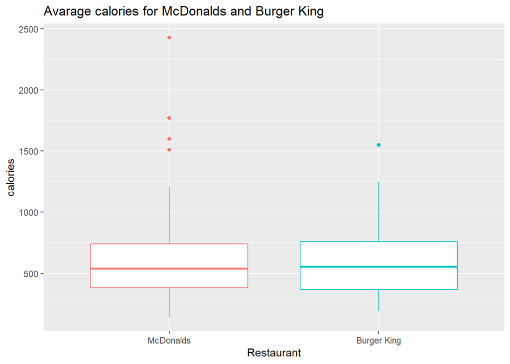

According to the plot and to the regression there is no difference between the two restaurants’ items with regards to calorie.